# Introduction

# Univariate Analysis

### What is the structure of your dataset?

There are 1599 wines in the dataset with 12 features. One of them is quality score that is calculated based on at least 3 ratings by wine experts. Other 11 features are physicochemical properties. Most of them are concentrations of different compounds like several acids, residual sugar, sodium chloride or ethanol. One feature is the density of the wine.

### What is/are the main feature(s) of interest in your dataset?

The main feature of interest is quality score. Since I am no wine expert, I have no idea in advance what physicochemical properties influence the quality score.

### What other features in the dataset do you think will help support your investigation into your feature(s) of interest?

I have no real clue what features influence the quality score. Only thing I could think of is citric acid concentration, because it has a wider range than other components with some wines not containing this compound at all. However, human sense of taste may be much more sensitive to some small changes in other compounds concentrations, so any compound in the set may have influence on the quality score.

### Did you create any new variables from existing variables in the dataset?

I created factor variable describing citric acid concentrations. Wines with less 0.05 g/l of citric acid were marked as “low”, wines with more than 0.55 as “high” and those in between “moderate”. I plan to analyze this later in bivariate analysis to see how citric acid affects wine quality scores.

### Of the features you investigated, were there any unusual distributions? Did you perform any operations on the data to tidy, adjust, or change the form of the data? If so, why did you do this?

Alcohol percentages had unusual distribution. It was clearly right skewed, but transformation of the x axis did not help to make it look any better.

# Bivariate Plots Section

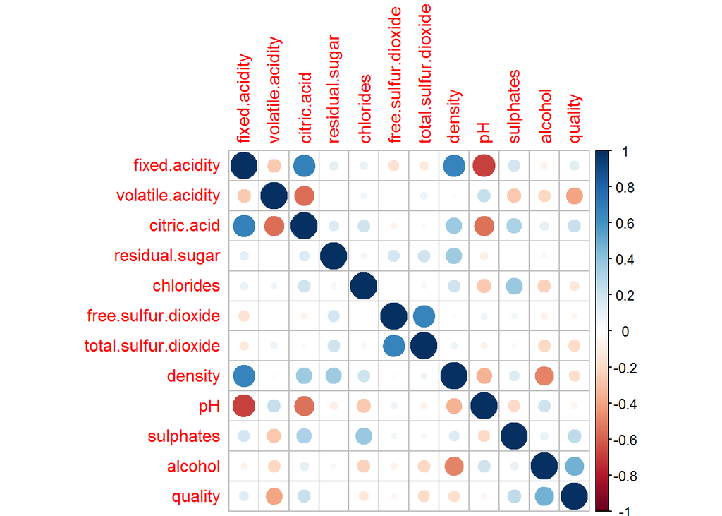

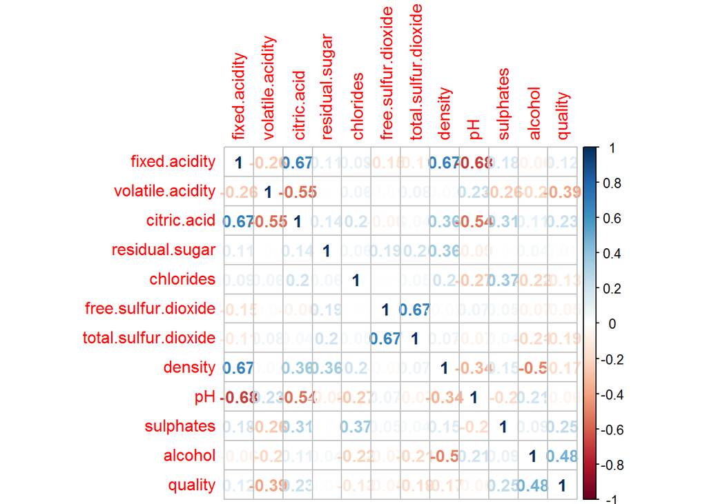

There is no strong correlation between different variables in this data set. Strongest positive correlation is 0.67 (citric acid vs fixed acidity, fixed acidity vs density and free sulfur dioxide and total sulfur dioxide). Strongest negative correlation is -0.68, between fixed acidity and pH.

Quality score had strongest correlation with alcohol (0.48) and volatile acidity (-0.39). Low correlations were with citric acid (0.23) and sulphates (0.25)

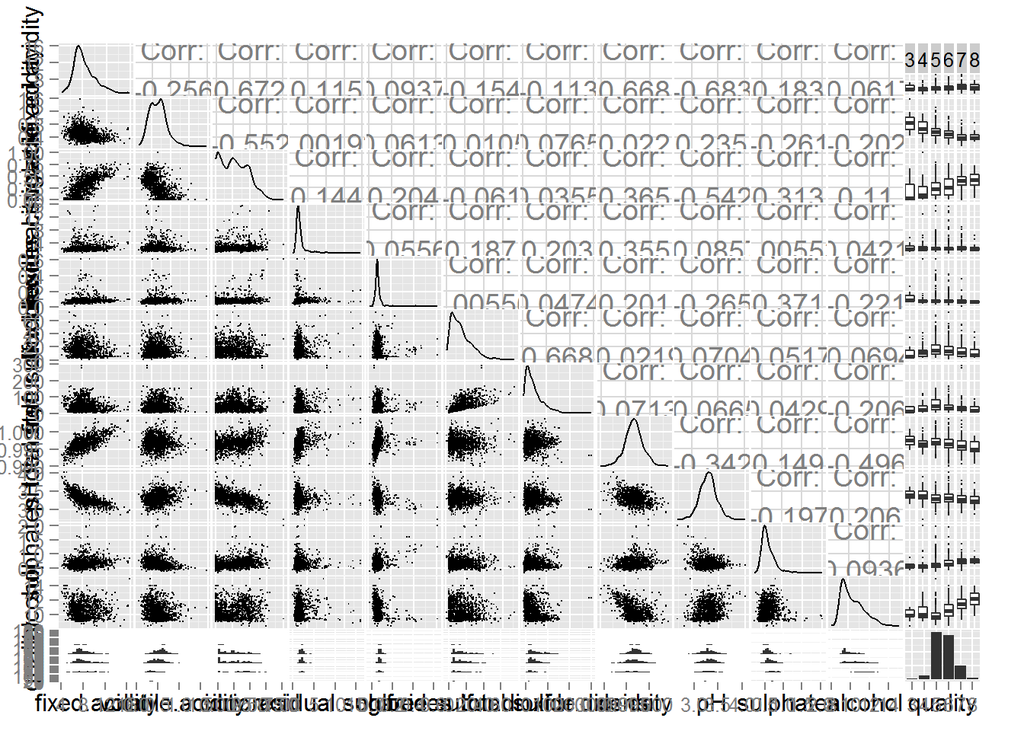

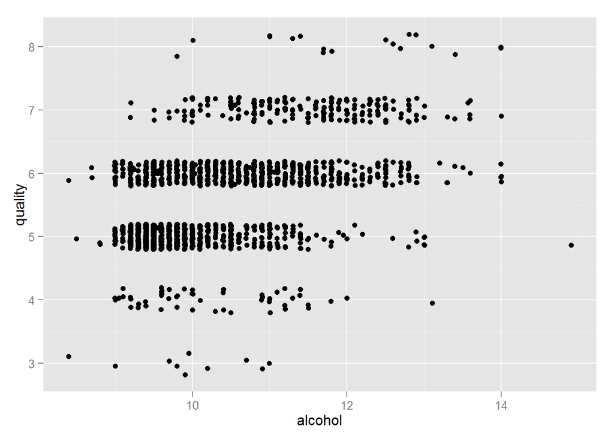

From dotplot it is apparent that only one wine with quality score 3 or 4 has more than 12% of alcohol. On the contrary, most wines with the highest quality score of 8 have 11 or more percent of alcohol. Only two wines with quality of 8 have less than 11% of alcohol (9.8 and 10).

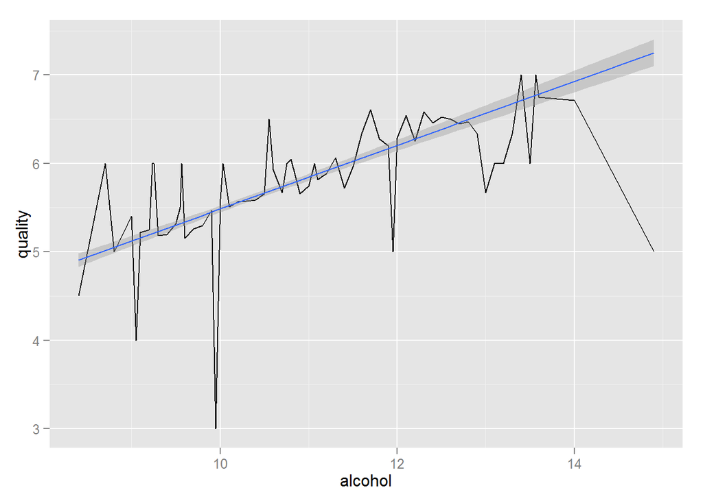

Plotting alcohol percentage vs quality shows that wine with more alcohol tend to have higher quality scores.

```
## wines$quality: 3
##    Min. 1st Qu.  Median    Mean 3rd Qu.    Max.
##   8.400   9.725   9.925   9.955  10.580  11.000
## --------------------------------------------------------
## wines$quality: 4
##    Min. 1st Qu.  Median    Mean 3rd Qu.    Max.
##    9.00    9.60   10.00   10.27   11.00   13.10
## --------------------------------------------------------
## wines$quality: 5
##    Min. 1st Qu.  Median    Mean 3rd Qu.    Max.
##     8.5     9.4     9.7     9.9    10.2    14.9
## --------------------------------------------------------
## wines$quality: 6
##    Min. 1st Qu.  Median    Mean 3rd Qu.    Max.
##    8.40    9.80   10.50   10.63   11.30   14.00
## --------------------------------------------------------
## wines$quality: 7
##    Min. 1st Qu.  Median    Mean 3rd Qu.    Max.
##    9.20   10.80   11.50   11.47   12.10   14.00
## --------------------------------------------------------
## wines$quality: 8
##    Min. 1st Qu.  Median    Mean 3rd Qu.    Max.
##    9.80   11.32   12.15   12.09   12.88   14.00
```

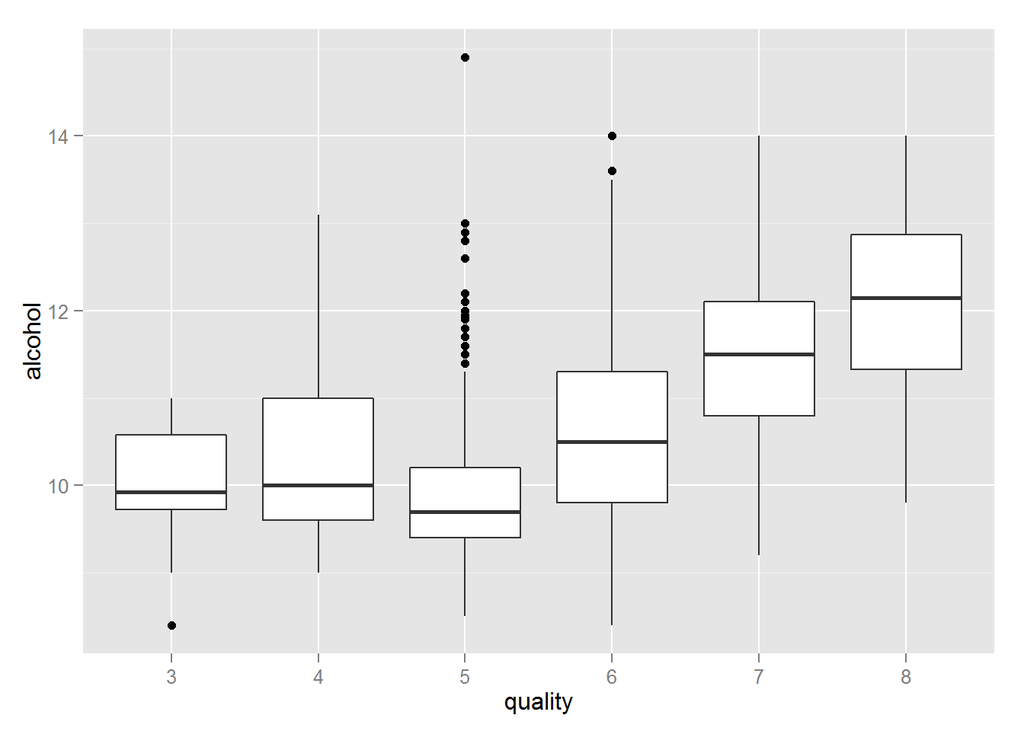

This trend can be seen looking at median and mean alcohol of different quality wines. Wines with quality of 7 and 8 clearly have higher mean and median alcohol percentage compared to lower quality wines.

```
## wines.alcohol.bucket
##   (8,9]  (9,10] (10,11] (11,12] (12,13] (13,15]
##      37     710     444     267     118      23
```

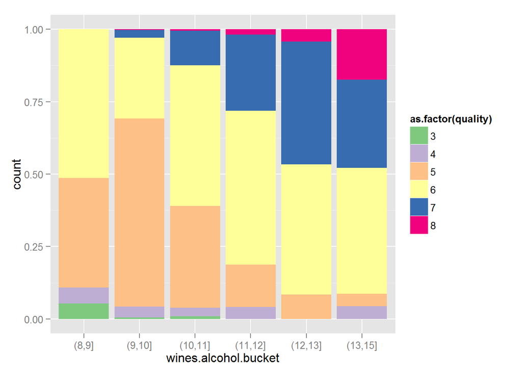

Wines with more alcohol clearly have higher quality scores.

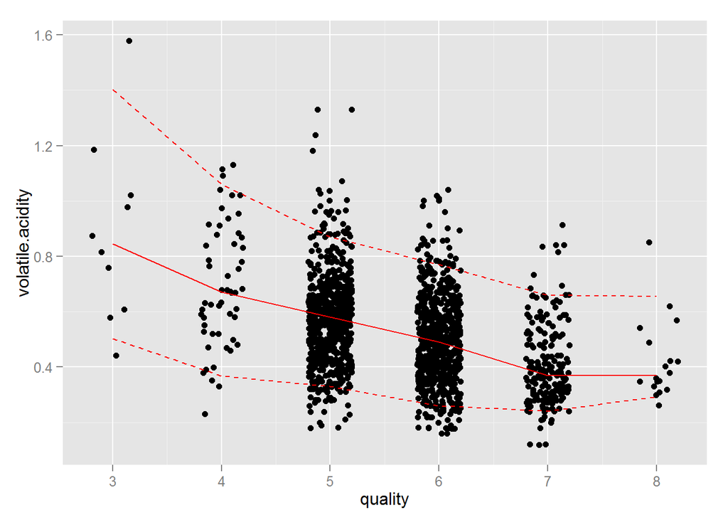

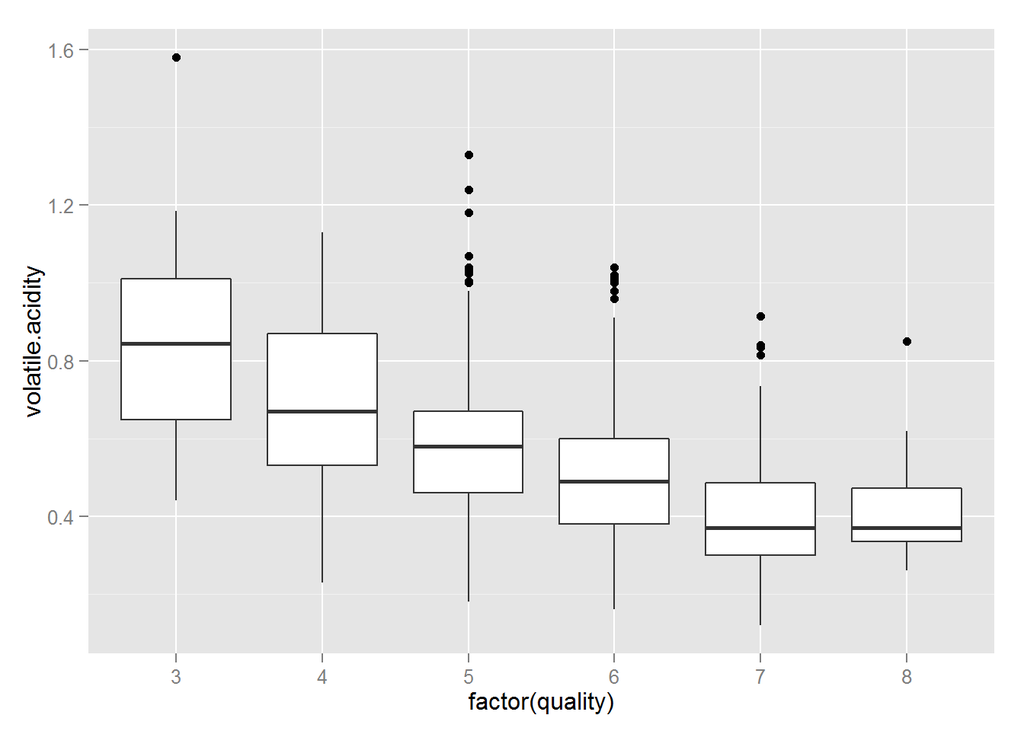

Quality is negatively correlated to volatile acidity. Higher quality wines have lower volatile acidity values.

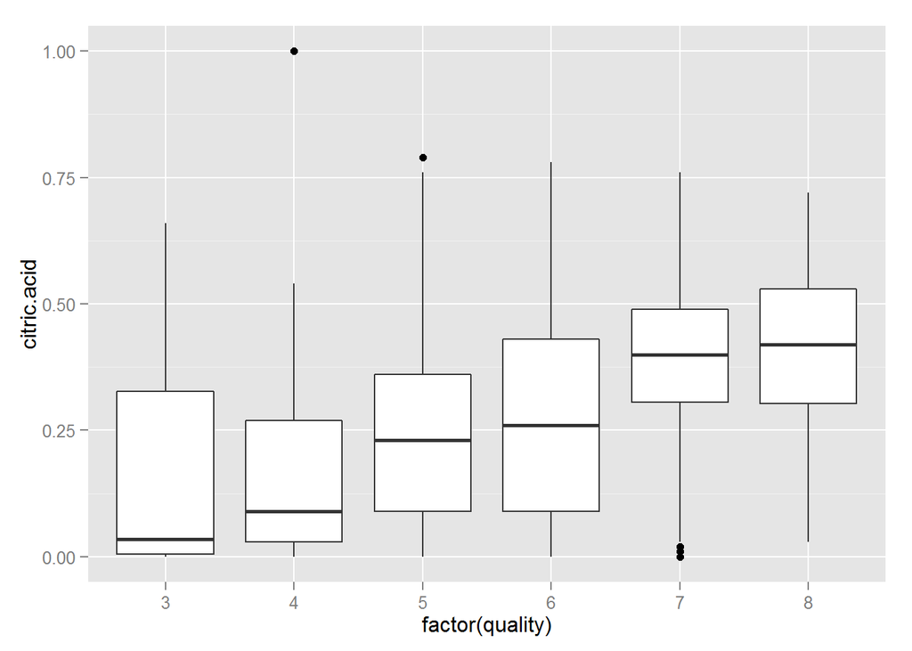

Median citric acid concentration of high quality wines (7 and 8) is higher compared to the rest.

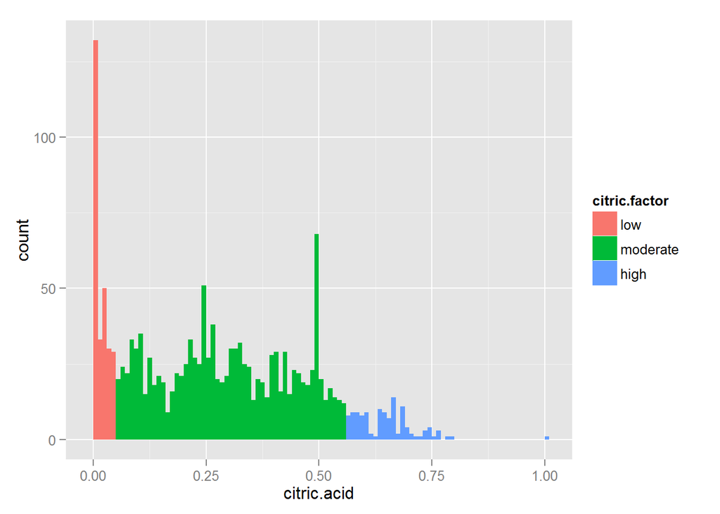

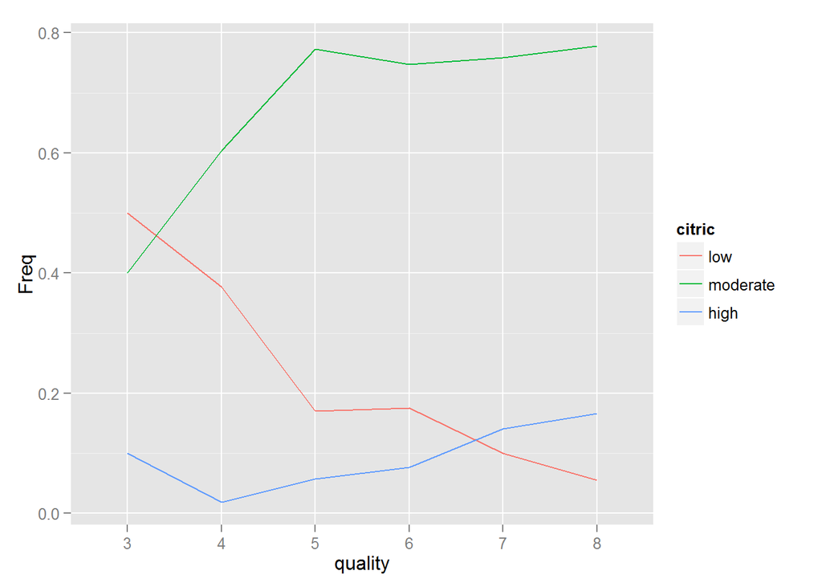

I partitioned wines into three categories based on citric acid concentration (low, moderate, high). Share of low citric acid concentration wines decreased as quality increased (from 0.5 of quality 3 wines to less than 0.1 of quality 8 wines). In contrary, share of high citric acid wines increased together with quality, although the change was not as prominent.

# Bivariate Analysis

### Talk about some of the relationships you observed in this part of the investigation. How did the feature(s) of interest vary with other features in the dataset?

Alcohol percentage had the strongest impact on quality scores. Wines with more alcohol had higher mean and median quality scores. Quality 7 wines had median alcohol percentage of 11.5 and quality 8 wines 12.15, while quality 3, 4, 5 wines had median alcohol percentage between 9.7 and 10. Categorizing wines based on alcohol showed the same trend, with highest alcohol values having higher shares of good quality wines.

Second contributor to wine quality was volatile acidity (correlation coefficient -0.39). Higher quality wines had lower values of volatile acidity.

I predicted beforehand that citric acid might influence wine quality, because it had a wide distribution, with some wines having 0 or very low values. It turned out that citric acid and quality have a weak correlation (0.23). Share of wines with very low citric acid concentration was higher among low quality wines, indicating that citric acid helps to make a wine better.

### Did you observe any interesting relationships between the other features (not the main feature(s) of interest)?

It was interesting to see what factors contribute to pH of a wine. Biggest contributor was fixed acidity (tartaric acid). Increase in citric acid, chlorides, sulphates and total sulfur dioxide also lowered pH of wines.

I predicted that density is most determined by alcohol percentage (since ethanol is lighter than water). However, alcohol was negatively correlated with density but the correlation was not strong (0.5). Surprisingly fixed acidity concentration had more influence on density (0.67).

### What was the strongest relationship you found?

The strongest correlation was between pH and fixed acidity.

# Multivariate Plots Section

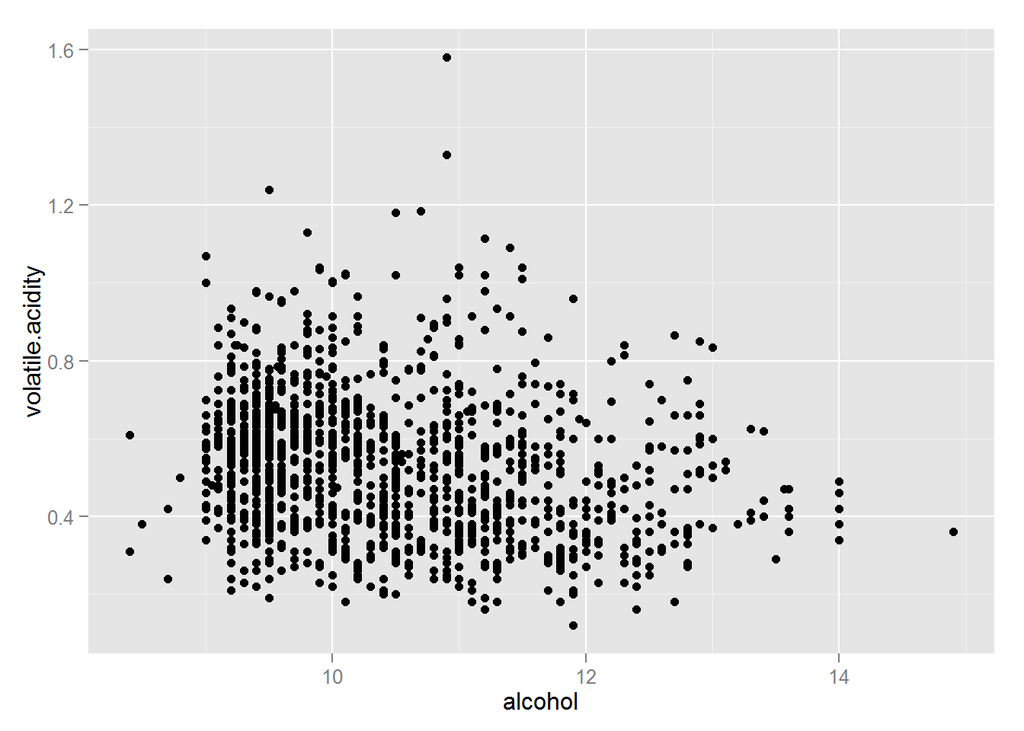

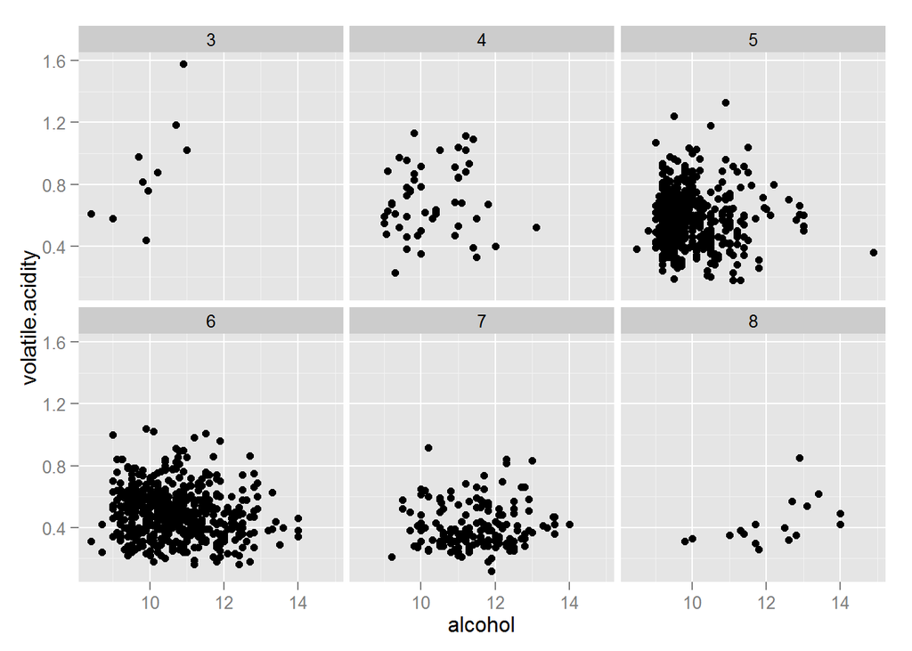

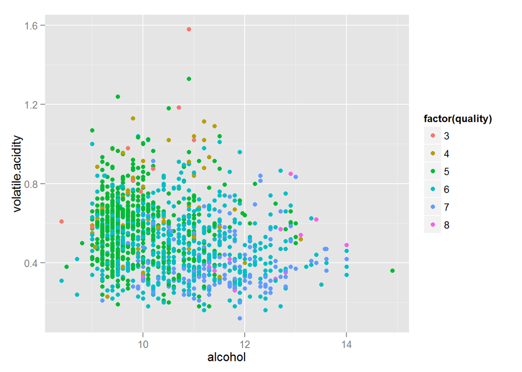

Two factors most contributing to wine quality are alcohol and volatile acidity. Plotting alcohol vs volatile acidity and quality on a single plot shows the tendency that wines with low volatile acidity and high alcohol have higher quality scores.

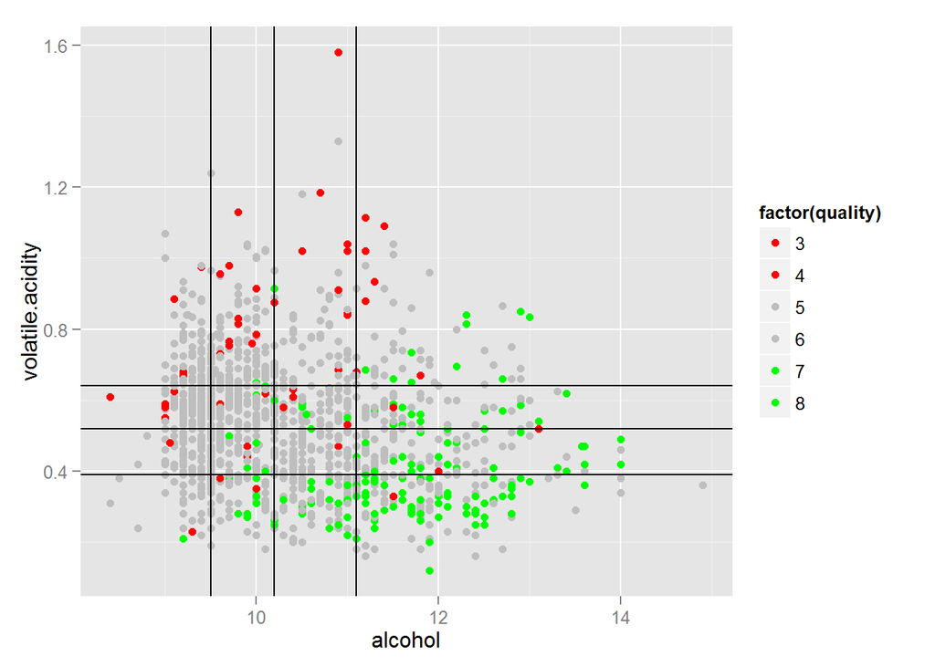

Colored points on alcohol vs volatile acidity graph did not give good enough visualization of the roles of these variable on wine quality. To get better visualization I wrote a function that creates heat map of continuous data. This function first breaks each variable into fractions based on quantile values. Then it creates a heat map of average third variable value (quality) for each fraction of wines.

On this graph black lines show 0.25, 0.5 and 0.75 quantiles. Following heat maps represent average qualities of each of these boxes.

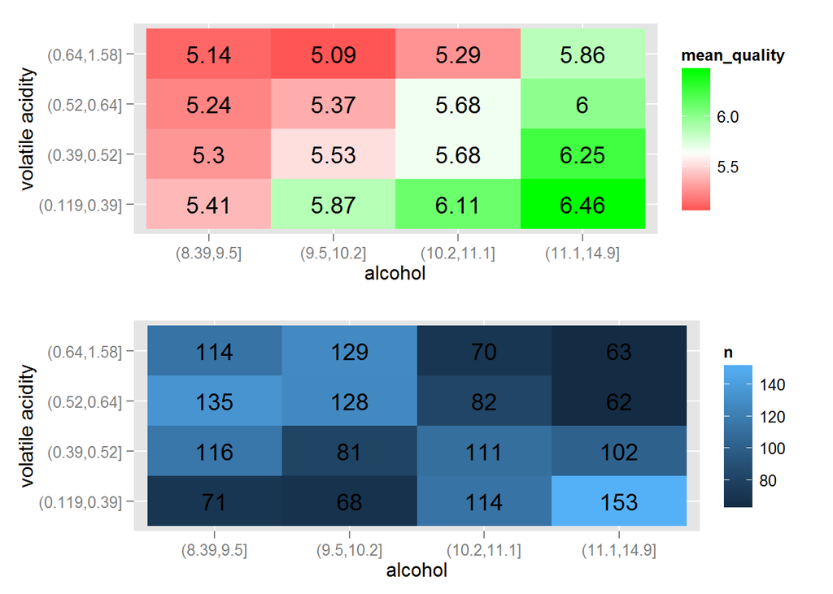

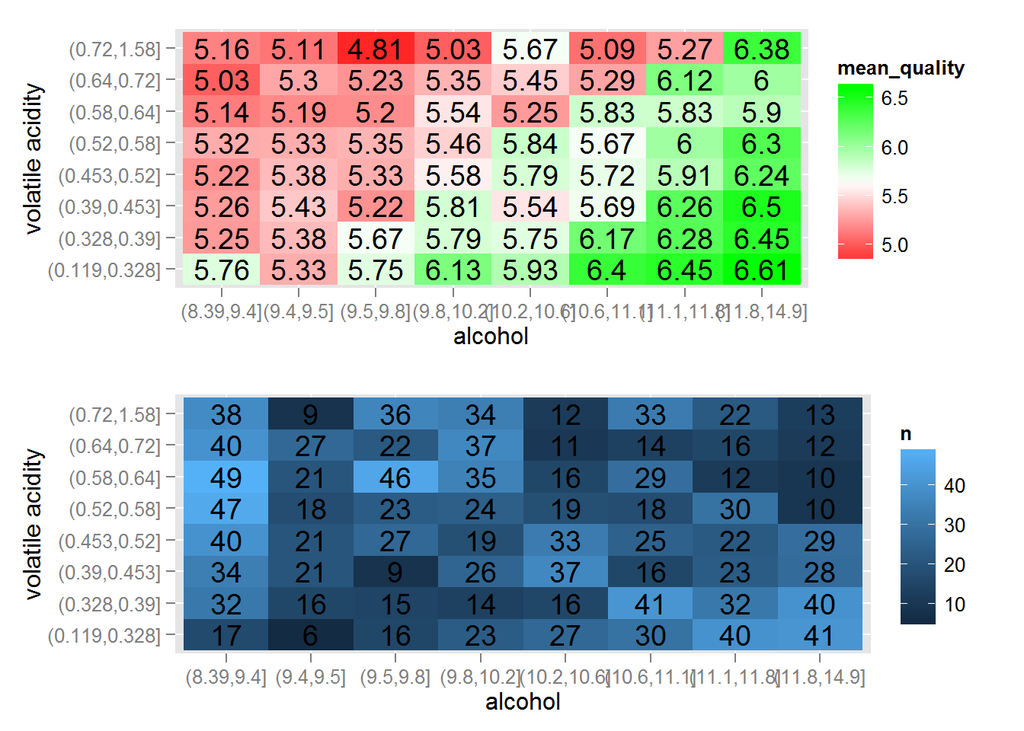

Average quality scores increase toward higher alcohol and lower volatile acidity.

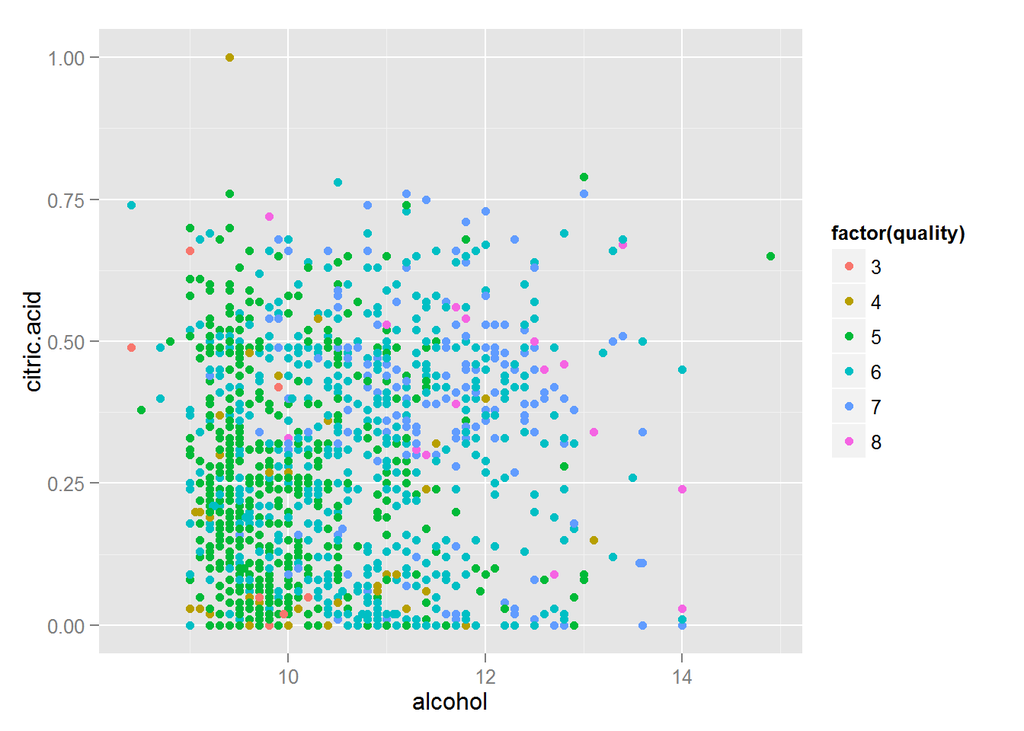